# Cyclotella cryptica heritability of growth at different salinities

##### At all salinities individually

```r
Herit <- function(df) {
  repeatability(data.vector = df$mean,
                geno.vector = df$Strain)
}

Hall_list <- dlply(.data=mean_growth,
              .variables=.(Treatment),
              .fun=Herit)

Heritability_all <- data.frame(matrix(unlist(Hall_list),nrow=5,byrow=TRUE))[,c(1,6:7,2:3)]
rownames(Heritability_all) <- c(0,2,12,24,36)
colnames(Heritability_all) <- c("H2","lb","ub","VG","Vres")
Heritability_all
```

```
##            H2        lb        ub           VG         Vres
## 0  0.99350262 0.9654709 0.9995513 1.790300e-02 0.0001170833
## 2  0.91063521 0.6168149 0.9934928 3.693907e-03 0.0003625000
## 12 0.85976138 0.4624183 0.9894351 7.709870e-03 0.0012575833
## 24 0.06697558 0.0000000 0.8474916 2.475926e-05 0.0003449167
## 36 0.90502849 0.5980270 0.9930590 5.724037e-03 0.0006006667
```

```
##        H2     lb     ub        VG      Vres
## 0  0.9941 0.9685 0.9996 0.0172306 0.0001027
## 2  0.9175 0.6405 0.9940 0.0034695 0.0003119
## 12 0.8905 0.5517 0.9919 0.0075946 0.0009334
## 24 0.1580 0.0000 0.8787 0.0000356 0.0001897
## 36 0.9110 0.6180 0.9935 0.0058887 0.0005754
```

```r
ggplot(aes(y=H2, x=rownames(Heritability_all)), data=Heritability_all) +
  geom_bar(stat="identity", width=.8, fill="indianred4") +
  geom_errorbar(aes(ymin=lb, ymax=ub), width=.2, data = Heritability_all) +
  xlab("Salinity") + ylab("Heritability")
```

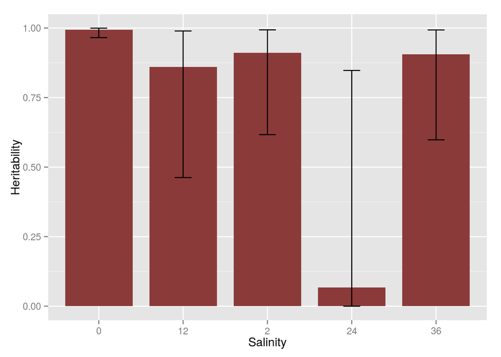

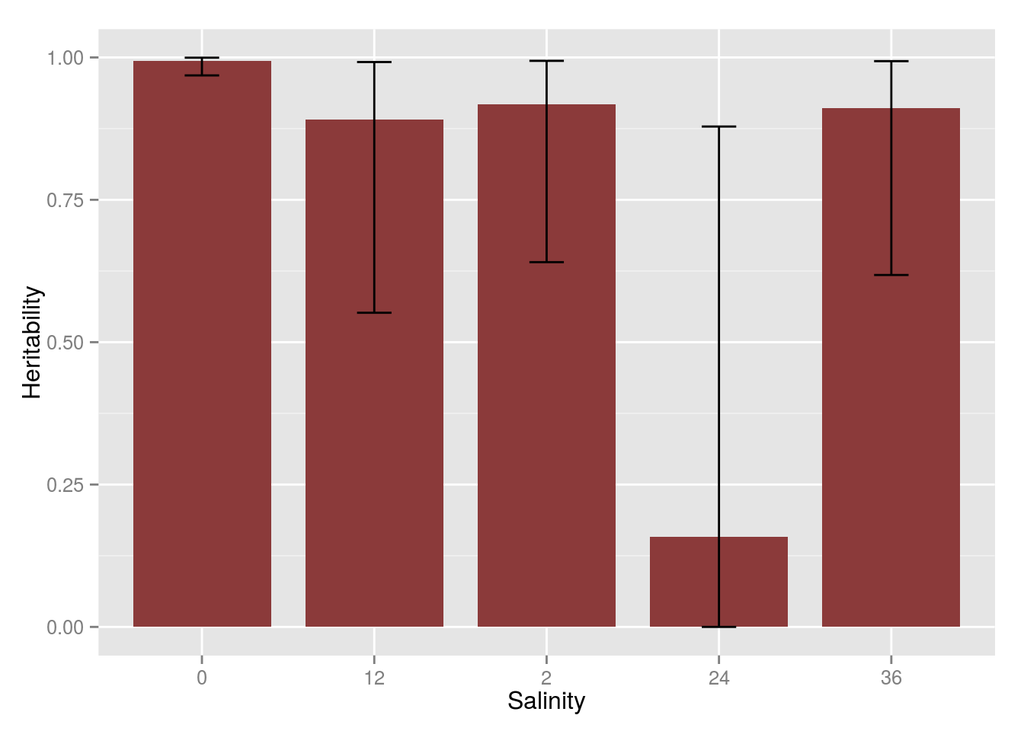

#### Growth curves for comparison

```r
 ggplot(data=last5,
      aes(x=Day, y=RF-Rfctrl, ymax=max(RF)*1.05,
        group=factor(Rep), shape=factor(Rep),
        colour=factor(Rep), linetype=factor(Rep))) +
      geom_line(size=0.6) +
      geom_point(size=3) +
      xlab("Day") +
      facet_grid(Strain ~ Treatment) +
      theme_bw()
```

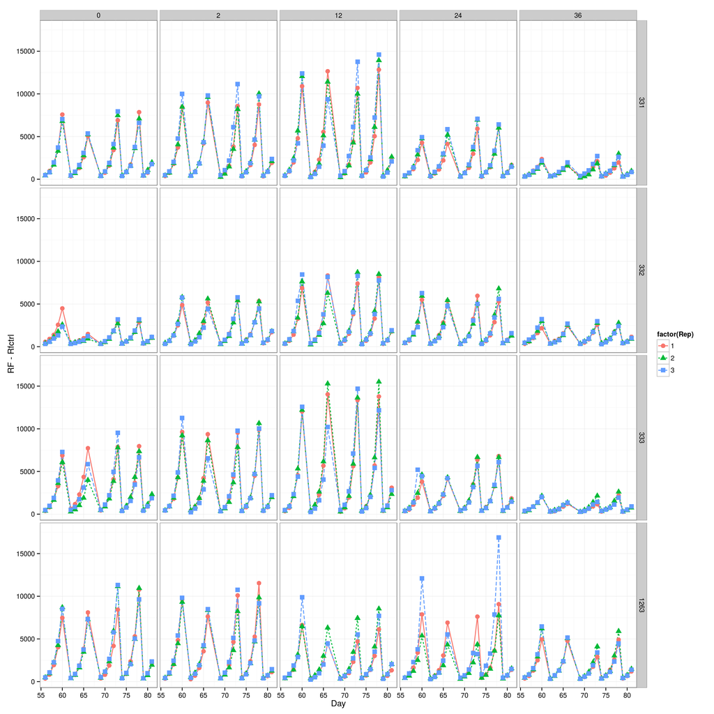

#### Don’t average over Transfers

Here we’ll have two levels of replication:

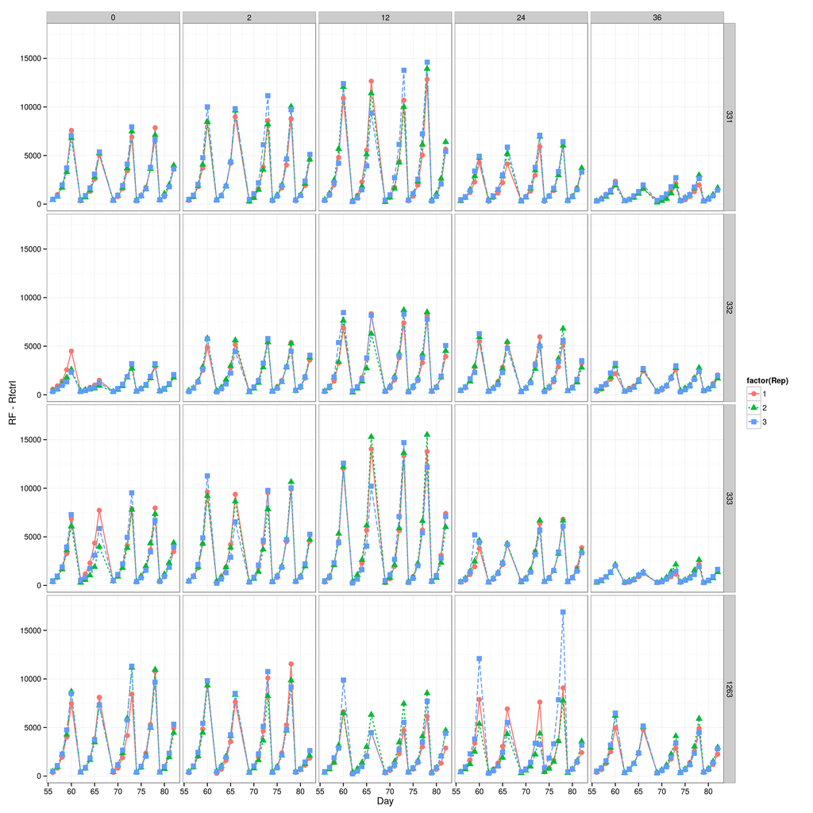

#### Don’t average over Transfers

In the analysis above we averaged the 5 estimates per Replicate into a mean slope. Here we’ll have two levels of replication:

- Technical replicates (`Replicate (Rep)`) and
- Sequential replicates (`Transfer (seqRep)`)

Start with the data frame with coefficients of the linear models.

```r
head(df_fits)
```

```
##   Treatment Strain Rep seqRep (Intercept)     trDay
## 1         0    331   1      N    5.501328 0.6783088
## 2         0    331   1      O    5.222334 0.6605789
## 3         0    331   1      P    5.238797 0.7195951
## 4         0    331   1      Q    5.268530 0.7356932
## 5         0    331   1      R    5.221328 0.7481144
## 6         0    331   2      N    5.332442 0.6963394
```

```
##   Treatment Strain Rep seqRep (Intercept)  trDay
## 1         0    331   1      N       5.501 0.6783
## 2         0    331   1      O       5.222 0.6606
## 3         0    331   1      P       5.239 0.7196
## 4         0    331   1      Q       5.269 0.7357
## 5         0    331   1      R       5.235 0.7398
## 6         0    331   2      N       5.332 0.6963
```

```r
Herit2 <- function(df) {
  repeatability(data.vector = df$trDay,
                geno.vector = df$Strain)
}

# agnostic about seqRep being nested within Rep
seqRep_Hall_list <- dlply(.data=df_fits,
              .variables=.(Treatment),
              .fun=Herit2)

seqRep_Heritability_all <- data.frame(matrix(unlist(seqRep_Hall_list),nrow=5,byrow=TRUE))[,c(1,6:7,2:3)]
rownames(seqRep_Heritability_all) <- c("0 ppt","2 ppt","12 ppt","24 ppt","36 ppt")
colnames(seqRep_Heritability_all) <- c("H2","lb","ub","VG","Vres")
seqRep_Heritability_all
```

```
##               H2        lb        ub          VG        Vres
## 0 ppt  0.8014596 0.5359179 0.9828694 0.017640715 0.004370019
## 2 ppt  0.5244003 0.2195968 0.9422012 0.003586847 0.003253056
## 12 ppt 0.7421947 0.4475543 0.9762846 0.007928143 0.002753883
## 24 ppt 0.0000000 0.0000000 0.3432545 0.000000000 0.003280930
## 36 ppt 0.6838973 0.3739007 0.9688984 0.005738605 0.002652428
```

```
##            H2     lb     ub       VG     Vres
## 0 ppt  0.8039 0.5400 0.9831 0.016967 0.004138
## 2 ppt  0.4977 0.1988 0.9364 0.003349 0.003381
## 12 ppt 0.7755 0.4953 0.9801 0.007797 0.002257
## 24 ppt 0.0000 0.0000 0.2862 0.000000 0.003017
## 36 ppt 0.7035 0.3974 0.9715 0.005918 0.002494
```

```r
ggplot(aes(y=H2, x=factor(rownames(seqRep_Heritability_all))), data=seqRep_Heritability_all) +
  geom_bar(stat="identity", width=.8, fill="indianred4") +
  geom_errorbar(aes(ymin=lb, ymax=ub), width=.2, data = seqRep_Heritability_all) +
  xlab("Salinity") + ylab("Heritability")
```

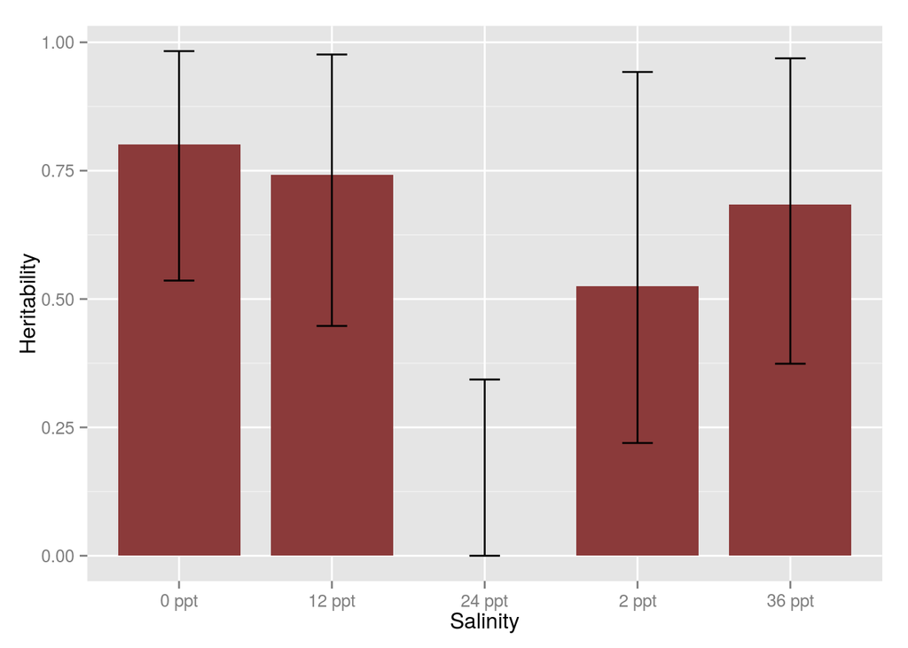

For comparison the slopes and their variation

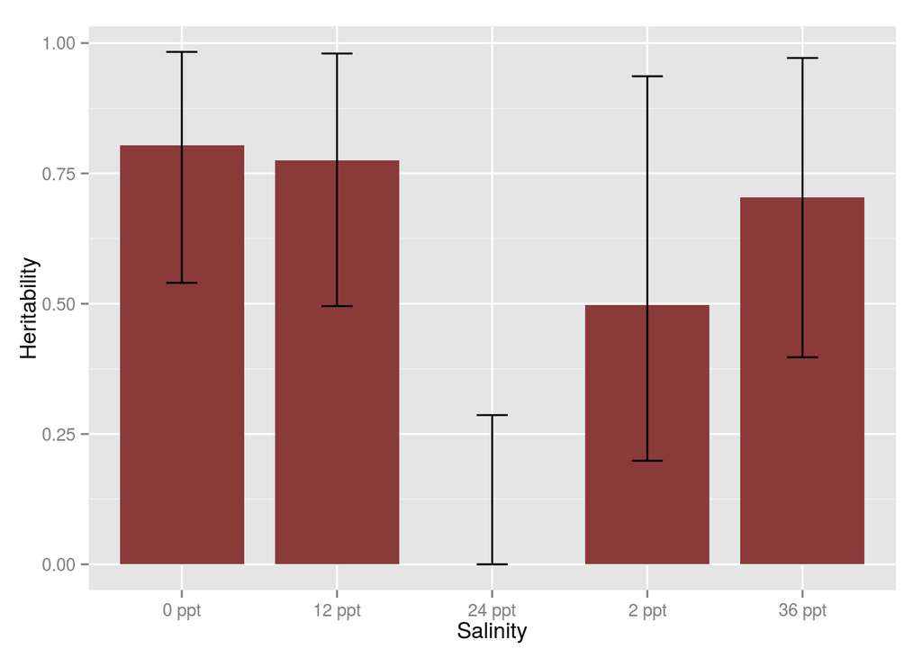

For comparison, the slopes and their variation

```r
rep_means <- ddply(.data=df_fits,
                   .variables=.(Treatment),
                   .fun=summarize,
                   Mean=round(mean(trDay),3),
                   Sdev=round(sd(trDay),3))

ggplot(aes(y=Mean, x=factor(Treatment)), data=rep_means) +
  geom_bar(stat="identity", width=.8, fill="indianred4") +
  geom_errorbar(aes(ymin=Mean-Sdev, ymax=Mean+Sdev), width=.2, data = rep_means) +
  xlab("Salinity") + ylab("Growth rate") #+
```

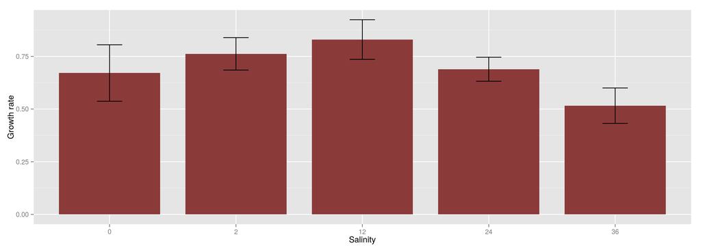

```r
  #facet_grid(~Strain)
```

#### Heritability within strains

```r
Herit3 <- function(df) {
  repeatability(data.vector = df$trDay,
                geno.vector = df$Strain,
                line.repeatability = TRUE)
}

# agnostic about seqRep being nested within Rep
line_Hall_list <- dlply(.data=df_fits,
              .variables=.(Treatment, Rep),
              .fun=Herit3)

line_Heritability_all <- data.frame(matrix(unlist(line_Hall_list),nrow=5,byrow=TRUE))[,c(1,6:7,2:3)]
rownames(line_Heritability_all) <- c("0 ppt","2 ppt","12 ppt","24 ppt","36 ppt")
colnames(line_Heritability_all) <- c("H2","lb","ub","VG","Vres")
line_Heritability_all
```

```
##               H2 lb ub          VG         Vres
## 0 ppt  0.9625617 NA NA 0.016149950 0.0006281434
## 2 ppt  0.7964013 NA NA 0.003947329 0.0010091280
## 12 ppt 0.9753094 NA NA 0.016746709 0.0004239548
## 24 ppt 0.0000000 NA NA 0.000000000 0.0006938263
## 36 ppt 0.8933681 NA NA 0.004671885 0.0005576334
```

[figure not shown]

```r
  #facet_grid(~Strain)
```

### Following Wood et al. 1987

- Replicate and Strain are random effects
- Replicate is nested within Strain and Treatment

```r
## install.packages("arm")
library(lme4)
library(arm)

display(lmer(lnRF ~ trDay*Strain + (1 + Strain | Treatment/Rep) + (1|Transfer) , data=last5))

SS <- lmer(mean ~ Treatment + (1 | Strain/Rep) , data=mean_growth)
fixef(SS)
ranef(SS)
anova(SS)
display(SS)
```

### cf. Edgar & Theriot 2003, JPhyc.

No random effects. Apparently these are difficult to estimate/interpret when the number of levels per factor is small. Here we have 4-5 levels per factor, which apparently is not enough for meaningful among block variance estimation (http://glmm.wikidot.com/faq). It might be possible to use these types of models when I combine the C. cryptica and C. wallercreekii data. We’ll have 9 Strains and possibly 10 sequential replicates. For now, use simple `lm` fixed effects model without interactions.

For 0 ppt first.

```r
last5zero <- droplevels(CSALT[which(CSALT$Treatment == 0 &
                                      CSALT$Transfer > 13 &
                                      CSALT$trDay > 1 &
                                      CSALT$trDay < 7), ])

last5zero <- mutate(last5zero,
                Treatment=factor(Treatment),
                Replicate=factor(Replicate),
                seqRep=factor(seqRep),
                trDay=trDay-1, # so that the first measurement is at day 1
                Rep=factor(Rep),
                Transfer=factor(Transfer),
                Strain=factor(Strain))
#head(last5zero)

# fit just the 0 ppt data
noRandEff <- lm(lnRF ~ trDay+Strain+seqRep+Rep , data=last5zero)

aovTable <- Anova(noRandEff, type=3)
aovTable
```

```
## Anova Table (Type III tests)
##
## Response: lnRF
##             Sum Sq  Df  F value  Pr(>F)
## (Intercept)    596   1 11181.80 < 2e-16 ***
## trDay          238   1  4473.62 < 2e-16 ***
## Strain          23   3   143.75 < 2e-16 ***
## seqRep           3   4    14.97 4.3e-11 ***
## Rep              0   2     2.21    0.11
## Residuals       15 277
## ---
## Signif. codes:  0 '***' 0.001 '**' 0.01 '*' 0.05 '.' 0.1 ' ' 1
```

```r
MSq <- aovTable[,1] / aovTable[,2] # divide SumSq by d.f to get MeanSq
H2 <- MSq[3]/sum(MSq[3:6]) # Var_strain / (Var_strain + Var_transfer + Var_replicate + Var_residual)
Vgen <- MSq[3] # Var_strain
Venv <- MSq[4] + MSq[5] # Var_strain + Var_replicate
Vres <- MSq[6] # Var_residual

data.frame(H2,Vgen,Venv,Vres)
```

```
##       H2  Vgen   Venv   Vres
## 1 0.8877 7.661 0.9161 0.0533
```

Scale to all Treatments:

```r
linMod <- function(DF) { lm(lnRF ~ trDay+Strain+seqRep+Rep , data=DF)}

noRandEff_all <- dlply(.data=last5,
                       .variables=.(Treatment),
                       .fun=linMod)

aovTable_all <- llply(.data= noRandEff_all,
                      .variables=.(Treatment),
                      .fun=Anova, type=3)

calcHerit <- function(aovTable) {
  MSq <- aovTable[,1] / aovTable[,2]
  H2 <- MSq[3]/sum(MSq[3:6])
  Vgen <- MSq[3]
  Venv <- MSq[4] + MSq[5]
  Vres <- MSq[6]
  data.frame(H2,Vgen,Venv,Vres)
}

broadSenseH <- ldply(.data=aovTable_all, .fun=calcHerit)
```

Compare the tables

```r
broadSenseH
```

```
##   .id     H2   Vgen   Venv    Vres
## 1   0 0.8877 7.6613 0.9161 0.05330
## 2   2 0.8742 1.2132 0.1455 0.02906
## 3  12 0.7997 2.3573 0.5556 0.03476
## 4  24 0.1261 0.1299 0.8674 0.03241
## 5  36 0.8583 3.9644 0.6262 0.02845
```

```r
seqRep_Heritability_all
```

```
##            H2     lb     ub       VG     Vres
## 0 ppt  0.8039 0.5400 0.9831 0.016967 0.004138
## 2 ppt  0.4977 0.1988 0.9364 0.003349 0.003381
## 12 ppt 0.7755 0.4953 0.9801 0.007797 0.002257
## 24 ppt 0.0000 0.0000 0.2862 0.000000 0.003017
## 36 ppt 0.7035 0.3974 0.9715 0.005918 0.002494
```

```r
Heritability_all
```

```
##        H2     lb     ub        VG      Vres
## 0  0.9941 0.9685 0.9996 0.0172306 0.0001027
## 2  0.9175 0.6405 0.9940 0.0034695 0.0003119
## 12 0.8905 0.5517 0.9919 0.0075946 0.0009334
## 24 0.1580 0.0000 0.8787 0.0000356 0.0001897
## 36 0.9110 0.6180 0.9935 0.0058887 0.0005754
```